# SP1 and ESR1 bulk calling card analysis

Jack Stenning

2023-10-31

# Background

## Rationale

After running the overlap analysis on SP1 calling cards and SP1 ChIP-Seq, I wanted to try the same analysis on my own ESR1 bulk calling cards and an existing ChIP-Seq data set - GSE109820. The processing of ESR1 calling cards was carried out by following the protocol.io pages:

‘Processing Bulk Calling Card Sequencing Data’ https://www.protocols.io/view/processing-bulk-calling-card-sequencing-data-n2bvjr25xlk5/v1 ‘Calling Peaks on piggyBac Calling Card Data’ https://www.protocols.io/view/calling-peaks-on-piggybac-calling-card-data-4r3l289dql1y/v1

This Rmd is executable, please make sure that the accompanying ‘Data’ directory has been extracted and stored into the same directory as this file. To save time, all of the code blocks up to ‘Peak calling’ have already been run and their outputs were included in the Data/ directory. Please make sure this directory is in the correct location before beginning.

# Method

## Working on the Univeristy of York Viking HPCC

### Prepare files for peak calling

Firstly, the barcode and index sequence had to be removed from the raw reads ER and WT calling cards. Samples were differentiated by using two different barcodes to denote whether the calling cards were directed by ER through the HyPB-ER fusion protein, or whether they are undirected by the Wild Type HyPB protein. Each replicate carried a unique Nextera index sequence to identify replicates within conditions.

Given that all of the barcodes are the same for samples within each condition, a loop script was written to trim the barcodes from ER directed and undirected calling cards.

```bash
#Load modules
module load cutadapt/3.4-GCCcore-10.3.0


#First step is to cut off the barcode and surrounding adapter
#For ER calling cards in this experiment, the barcode is the same - CGT

cd 202306_JS_BulkCC/
for direct in ER*; do
cd "$direct"
gunzip *.gz
    for file in *1.fq; do
        cutadapt \
            -g ^CGTTTTACGCAGACTATCTTTCTAGGGTTAA \
            --minimum-length 1 \
            --discard-untrimmed \
            -e 0 \
            --no-indels \
           -o "$file"TrimmedBC.fq \
           "$file"
    done
    cd ../
done
cd ../

#For WT calling cards in this experiment, the barcode is the same - TAG

cd 202306_JS_BulkCC/
for direct in WT*; do
cd "$direct"
gunzip *.gz
    for file in *1.fq; do
        cutadapt \
            -g ^TAGTTTACGCAGACTATCTTTCTAGGGTTAA \
            --minimum-length 1 \
            --discard-untrimmed \
            -e 0 \
            --no-indels \
           -o "$file"TrimmedBC.fq \
           "$file"
    done
    cd ../
done
cd ../
```

However, although the index sequence is different for each of the replicates within a condition, trimming of these sequences can be carried out in one script by replacing the index sequence with ‘NNNNNNNNNN’ as cut adapt can handle degenerate sequence within adaptors. The code below is an example of the processing for a single replicate - ER1, other replicates use the same code, with the file name and index sequence supplemented for the correct versions.

```bash
#Load modules
module load cutadapt/3.4-GCCcore-10.3.0

#Cut adapt will take degenerate sequence for indexes - NNNNNNNNNN
cd 202306_JS_BulkCC/
for dir in *; do
  cd "$dir"
  echo "Now in "$dir""
  for file in *TrimmedBC.fq; do
    cutadapt \
    -a CTGTCTCTTATACACATCTCCGAGCCCACGAGACTNNNNNNNNNNTCTCGTATGCCGTCTTCTGCTTG \
    --minimum-length 1 \
    -o "$file"_fulltrimmed.fastq \
    "$file"
  done
  cd ../
done
cd ../
```

Once all of the files have been trimmed, the reads can be aligned to hg38. Contrary to the protocol.io, BWA MEM was used as novoalign was not available on the Viking HPCC. The code below is an example of the processing for a single replicate - ER1, other replicates use the same code, with the file name supplemented for the correct versions.

```bash
#purge then load modules
module purge
module load deepTools/3.5.0-foss-2021a
module load BWA/0.7.17-foss-2019b
module load SAMtools/1.16.1-GCC-11.3.0
module load BEDTools/2.30.0-GCC-11.2.0

cd 202306_JS_BulkCC/
for dir in *; do
  cd "$dir"
  echo "Now in "$dir""
  for file in *fulltrimmed.fastq; do
    echo "Processing "$file""
      bwa mem -p -t 40 /mnt/scratch/users/jps558/staging/hg38/hg38.fa "$file" > "$file".sam
      done
      cd ../
done
cd ../
```

After, the reads can be sorted into a .bam file.

```bash
#Purge then load modules
        module purge
        module load SAMtools/1.16.1-GCC-11.3.0

#Sorting to bam
cd 202306_JS_BulkCC/
for dir in *; do
  cd "$dir"
  echo "now in "$dir""
    for file in *.sam; do
      echo "$file"
        samtools view \
            -bS -h -F 260 \
             "$file" | \
            samtools sort - -o "$file"_mapped.bam
        done
    cd ../
done
cd ../
```

After this step, the TagBam.py script from Arnhav Moudgil’s GitHub - https://github.com/arnavm/calling_cards -is run. Similarly to the adaptor trimming step, given that all of the barcodes are the same for samples within each condition, a loop script was written to trim the barcodes from ER directed and undirected calling cards. However, as the index sequence is different for each of the replicates within a condition, trimming of these sequences must be done individually for each replicate.

In order to execute python code on the Viking2 HPCC I first had to set up a virtual environment.

```bash
### Set up env
module load Miniconda3/23.5.2-0
conda env create -f CallingCardsPython.yaml
cd ../
```

```bash
#Purge then load modules
module purge
module load SAMtools/1.16.1-GCC-11.3.0
module load BEDTools/2.30.0-GCC-11.2.0

#Activate python environment
module load Miniconda3/23.5.2-0
#Activate python environment

source activate CallingCardsPython

#Tag barcodes
cd 202306_JS_BulkCC/
for direct in ER*; do
cd "$direct"
    for file in *mapped.bam; do
        python ../../TagBam.py \
           --tag XP:Z:CGT \
           "$file" \
           "$file"_tagged.bam
    done
    cd ../
done
for direct in WT*; do
cd "$direct"
    for file in *mapped.bam; do
        python ../../TagBam.py \
           --tag XP:Z:TAG \
           "$file" \
           "$file"_tagged.bam
    done
    cd ../
done
cd ../

#TAG WT barcodes
echo "bash TAG WT barcodes"
cd 202306_JS_BulkCC/
for direct in WT*; do
cd "$direct"
    for file in *mapped.bam; do
        python ../../TagBam.py \
           --tag XP:Z:TAG \
           "$file" \
           "$file"_tagged.bam
    done
    cd ../
done
cd ../
```

Below is an example of one of the TagBam.py index scripts run. The code below is an example of the processing for a single replicate - ER2, other replicates use the same code, with the file name and index sequence supplemented for the correct versions.

```bash
echo "bash tag index"
cd 202306_JS_BulkCC/
#ER1
cd ER1/
for file in *_tagged.bam; do
    python ../../TagBam.py \
       --tag XJ:Z:ACTCGCTA \
       "$file" \
       "$file"_tagged2.bam
done
cd ../
#ER2
cd ER2/
for file in *_tagged.bam; do
    python ../../TagBam.py \
       --tag XJ:Z:GGAGCTAC \
       "$file" \
       "$file"_tagged2.bam
done
cd ../
#ER3
cd ER3/
for file in *_tagged.bam; do
    python ../../TagBam.py \
       --tag XJ:Z:GCGTAGTA \
       "$file" \
       "$file"_tagged2.bam
done
cd ../
#ER5
cd ER5/
for file in *_tagged.bam; do
    python ../../TagBam.py \
       --tag XJ:Z:CGGAGCCT \
       "$file" \
       "$file"_tagged2.bam
done
cd ../
#ER6
cd ER6/
for file in *_tagged.bam; do
    python ../../TagBam.py \
       --tag XJ:Z:TACGCTGC \
       "$file" \
       "$file"_tagged2.bam
done
cd ../
################################################################################################
#WT1
cd WT1/
for file in *_tagged.bam; do
    python ../../TagBam.py \
       --tag XJ:Z:ATGCGCAG \
       "$file" \
       "$file"_tagged2.bam
done
cd ../
#WT2
cd WT2/
for file in *_tagged.bam; do
    python ../../TagBam.py \
       --tag XJ:Z:TAGCGCTC \
       "$file" \
       "$file"_tagged2.bam
done
cd ../
#WT3
cd WT3/
for file in *_tagged.bam; do
    python ../../TagBam.py \
       --tag XJ:Z:ACTGAGCG \
       "$file" \
       "$file"_tagged2.bam
done
cd ../
#WT4
cd WT4/
for file in *_tagged.bam; do
    python ../../TagBam.py \
       --tag XJ:Z:CCTAAGAC \
       "$file" \
       "$file"_tagged2.bam
done
cd ../
#WT5
cd WT5/
for file in *_tagged.bam; do
    python ../../TagBam.py \
       --tag XJ:Z:CGATCAGT \
       "$file" \
       "$file"_tagged2.bam
done
cd ../
#WT6
cd WT6/
for file in *_tagged.bam; do
    python ../../TagBam.py \
       --tag XJ:Z:TGCAGCTA \
       "$file" \
       "$file"_tagged2.bam
done
cd ../
```

Once all of the replicates have had their index tag added, the insertion sites can be annotated using the AnnotateInsertionSites.py script. After the .bam files can be indexed

```bash
echo "bash annotate insert"
#Purge then load modules
module purge
module load SAMtools/1.16.1-GCC-11.3.0
module load BEDTools/2.30.0-GCC-11.2.0

#Prepare python environment
module load Miniconda3/23.5.2-0
source activate CallingCardsPython

cd 202306_JS_BulkCC
for dir in *; do
    cd "$dir"
    echo "$dir"
    for file in *tagged2.bam; do
        python ../../AnnotateInsertionSites.py \
            --transposase PB \
            -f \
            "$file" \
            /mnt/scratch/users/jps558/staging/hg38/hg38.2bit \
           "$file"_final.bam
        done
    for mile in *mapped.bam_tagged.bam_tagged2.bam_final.bam; do
            mv "$mile" "${mile%%mapped.bam_tagged.bam_tagged2.bam_final.bam}final.bam"
        done
    cd  ../
done
cd ../
```

```bash
echo "bash index bam"
module purge
module load SAMtools/1.16.1-GCC-11.3.0

cd 202306_JS_BulkCC/
for dir in *; do
    cd "$dir"
    echo "$dir"
    for file in *final.bam; do
        samtools index "$file"
        done
    cd  ../
done
cd ../
```

Finally, the files can be cleaned up and concatenated into a single file for easier use down the pipeline.

```bash
echo "bash convert bam to CC"
module purge
module load SAMtools/1.16.1-GCC-11.3.0
module load BEDTools/2.30.0-GCC-11.2.0

module load Miniconda3/23.5.2-0
source activate CallingCardsPython

cd 202306_JS_BulkCC/
mkdir outputs
mkdir outputs/ER
mkdir outputs/WT
for dir in ER*; do
    cd "$dir"
    for file in *final.bam; do
        python ../../BamToCallingCard.py \
            -b XP XJ \
            -i "$file" \
            > "$file".qbed
        done
    for mile in *final.bam.qbed; do
            mv "$mile" "${mile%%final.bam.qbed}.qbed"
        done
  for save in *.qbed; do
    cp *.qbed ../outputs/ER
    done
  for store in *final.bam*; do
    cp "$store" ../outputs/ER
    done
    cd  ../
done

for dir in WT*; do
    cd "$dir"
    for file in *final.bam; do
        python ../../BamToCallingCard.py \
            -b XP XJ \
            -i "$file" \
            > "$file".qbed
        done
    for mile in *final.bam.qbed; do
            mv "$mile" "${mile%%final.bam.qbed}.qbed"
        done
  for save in *.qbed; do
    cp *.qbed ../outputs/WT
    done
  for store in *final.bam*; do
    cp "$store" ../outputs/WT
    done
    cd  ../
done

#Cat ER
cd outputs/ER
mkdir combined/
cat ER*HF552DSX7_L2_1_.qbed | bedtools sort -i > combined/ER_HyPB_HF552DSX7_L2_1.qbed
cat ER*HFK3FDSX7_L2_1_.qbed | bedtools sort -i > combined/ER_HyPB_HFK3FDSX7_L2_1.qbed
cat ER*.qbed | bedtools sort -i > combined/ER_HyPB_EKDL230008858.qbed
samtools merge ER_HyPB_EKDL230008858_final.bam ER*final.bam
cd combined/
mv *qbed ../
cd ../../

#Cat WT
cd WT
mkdir combined/
cat WT*HF552DSX7_L2_1_.qbed | bedtools sort -i > combined/WT_HyPB_HF552DSX7_L2_1.qbed
cat WT*HFK3FDSX7_L2_1_.qbed | bedtools sort -i > combined/WT_HyPB_HFK3FDSX7_L2_1.qbed
cat WT*.qbed | bedtools sort -i > combined/WT_HyPB_EKDL230008858.qbed
samtools merge WT_HyPB_EKDL230008858_final.bam WT*final.bam
cd combined/
mv *qbed ../
cd ../../../../
```

You can also clean up intermediary file types if you dont remove the files you are interested in

```bash
for dir in 202306_JS_BulkCC/*; do
    cd "$dir"
    for file in *Trimmed*; do
        rm "$file"
        done
    for dile in *.sam; do
        rm "$dile"
        done
    for mile in tagged*.bam; do
        rm "$mile"
        done
    cd ../
    done
cd ../
```

### Peak calling

Before calling peaks, it’s necessary to generate a list of ‘TTAA’ tetranucleotides throughout hg38. This is used to generate an estimate for the expected uniform insertion rate of calling cards because the HyPB transposase inserts almost exclusively at these sites. This can be done using the kmer program. There is an optional step that can be taken to use only canonical chromosomes.

```bash
chmod +x kmer
./kmer ../staging/hg38/hg38.fa TTAA > ../staging/hg38/hg38_TTAA.bed

grep -v '_' ../staging/hg38/hg38_TTAA.bed > ../staging/hg38/hg38_TTAA_canon.bed
```

the qBED files should then be sorted before processing further.

```bash
module load BEDTools/2.30.0-GCC-11.2.0
cd 202306_JS_BulkCC/outputs
#ER
cd ER
bedtools sort -i ER_HyPB_HF552DSX7_L2_1.qbed > ER_HyPB_HF552DSX7_L2_1_sorted.qbed
bedtools sort -i ER_HyPB_HFK3FDSX7_L2_1.qbed > ER_HyPB_HFK3FDSX7_L2_1_sorted.qbed
bedtools sort -i ER_HyPB_EKDL230008858.qbed > ER_HyPB_EKDL230008858_sorted.qbed
mkdir notsorted
cp *1.qbed notsorted/
cp *8.qbed notsorted/
cd ../
#WT
cd WT
bedtools sort -i WT_HyPB_HF552DSX7_L2_1.qbed > WT_HyPB_HF552DSX7_L2_1_sorted.qbed
bedtools sort -i WT_HyPB_HFK3FDSX7_L2_1.qbed > WT_HyPB_HFK3FDSX7_L2_1_sorted.qbed
bedtools sort -i WT_HyPB_EKDL230008858.qbed > WT_HyPB_EKDL230008858_sorted.qbed
mkdir notsorted
cp *1.qbed notsorted/
cp *8.qbed notsorted/
cd ../../../
```

I had previously filtered blacklisted sites from SP1 calling cards before creating block files, I will do the same here but will also process the unfiltered reads alongside.

```bash
#Load modules
module load BEDTools/2.30.0-GCC-11.2.0

cd 202306_JS_BulkCC/outputs/ER

#Filter
for file in *sorted.qbed; do
    bedtools subtract -a  "$file" -b /mnt/scratch/users/jps558/staging/hg38/Blacklist/hg38-blacklist.v2.bed > "$file"_filtered.qbed
  done
cd ../WT
for file in *sorted.qbed; do
    bedtools subtract -a  "$file" -b /mnt/scratch/users/jps558/staging/hg38/Blacklist/hg38-blacklist.v2.bed > "$file"_filtered.qbed
  done
cd /mnt/scratch/users/jps558/Stenning_Data_Analysis
```

Then, the sorted files can be used to generate the blocks file, this segments the reads into regions that contain a uniform insertion rate. This is used by later scripts to determine which insertions are background, and which are genuine re-directed insertions. Finally, the files can be used to call peaks, and there are separate scripts used for directed and un-directed calling cards.

```bash
module purge
module load SAMtools/1.16.1-GCC-11.3.0
module load BEDTools/2.30.0-GCC-11.2.0
module load Miniconda3/23.5.2-0


#Activate python environment


source activate CallingCardsPython



cd 202306_JS_BulkCC/outputs/ER
for file in *filtered.qbed; do
  echo "$file"
  #python /mnt/scratch/users/jps558/Stenning_Data_Analysis/SegmentCCF.py "$file" | sed -e '/^\s*$/d' > "$file".blocks
  python /mnt/scratch/users/jps558/Stenning_Data_Analysis/BBPeakCaller_TF.py -a 0.05 -m fdr_bh -d 250 -x 5000 \
    -i "$file"_no_r_intermediate.csv \
    "$file" \
      "$file".blocks \
      ../WT/WT_HyPB_EKDL230008858_sorted.qbed \
    "$file"_fdr_bh_0.05_peaks_nor.bed
  python /mnt/scratch/users/jps558/Stenning_Data_Analysis/BBPeakCaller_TF.py -a 0.05 -r -m fdr_bh -d 250 -x 5000 \
      -i "$file"_r_intermediate.csv \
    "$file" \
      "$file".blocks \
      ../WT/WT_HyPB_EKDL230008858_sorted.qbed \
    "$file"_fdr_bh_0.05_peaks_r.bed
  done
cd ../WT
for file in *filtered.qbed; do
  echo "$file"
  #python /mnt/scratch/users/jps558/Stenning_Data_Analysis/SegmentCCF.py "$file" | sed -e '/^\s*$/d' > "$file".blocks
  python /mnt/scratch/users/jps558/Stenning_Data_Analysis/BBPeakCaller_BRD4.py -p 30 -d 12500 \
    -i "$file"_p30_intermediate.csv \
    "$file" \
    "$file".blocks \
    /mnt/scratch/users/jps558/staging/hg38/hg38_TTAA.bed \
    "$file"_p30_peaks.bed
  python /mnt/scratch/users/jps558/Stenning_Data_Analysis/BBPeakCaller_BRD4.py -p 62 -d 12500 \
    -i "$file"_p62_intermediate.csv \
    "$file" \
    "$file".blocks \
    /mnt/scratch/users/jps558/staging/hg38/hg38_TTAA.bed \
      "$file"_p62_peaks.bed
  python /mnt/scratch/users/jps558/Stenning_Data_Analysis/BBPeakCaller_BRD4.py -p 9 -d 12500 \
    -i "$file"_p9_intermediate.csv \
    "$file" \
    "$file".blocks \
    /mnt/scratch/users/jps558/staging/hg38/hg38_TTAA.bed \
    "$file"_p9_peaks.bed
  done
cd ../
  #Clean up block file ends

# Capture the part of the filename you want to keep
prefix1="ER_HyPB_EKDL230008858"
prefix2="ER_HyPB_HF552DSX7_L2_1"
prefix3="ER_HyPB_HFK3FDSX7_L2_1"
# Using 'mv' and 'sed' to rename the files
cd ER
for file in "${prefix1}"*_sorted.qbed_filtered.qbed_fdr_bh_0.05_peaks_nor.bed; do
    new_name=$(echo "$file" | sed "s/${prefix1}_sorted.qbed_filtered.qbed_/${prefix1}_/")
    mv "$file" "$new_name"
done
for file in "${prefix2}"*_sorted.qbed_filtered.qbed_fdr_bh_0.05_peaks_nor.bed; do
    new_name=$(echo "$file" | sed "s/${prefix2}_sorted.qbed_filtered.qbed_/${prefix2}_/")
    mv "$file" "$new_name"
done
for file in "${prefix3}"*_sorted.qbed_filtered.qbed_fdr_bh_0.05_peaks_nor.bed; do
    new_name=$(echo "$file" | sed "s/${prefix3}_sorted.qbed_filtered.qbed_/${prefix3}_/")
    mv "$file" "$new_name"
done
for file in "${prefix1}"*_sorted.qbed_filtered.qbed_fdr_bh_0.05_peaks_r.bed; do
    new_name=$(echo "$file" | sed "s/${prefix1}_sorted.qbed_filtered.qbed_/${prefix1}_/")
    mv "$file" "$new_name"
done
for file in "${prefix2}"*_sorted.qbed_filtered.qbed_fdr_bh_0.05_peaks_r.bed; do
    new_name=$(echo "$file" | sed "s/${prefix2}_sorted.qbed_filtered.qbed_/${prefix2}_/")
    mv "$file" "$new_name"
done
for file in "${prefix3}"*_sorted.qbed_filtered.qbed_fdr_bh_0.05_peaks_r.bed; do
    new_name=$(echo "$file" | sed "s/${prefix3}_sorted.qbed_filtered.qbed_/${prefix3}_/")
    mv "$file" "$new_name"
done
cd ../
# Capture the part of the filename you want to keep
prefix1="WT_HyPB_EKDL230008858"
prefix2="WT_HyPB_HF552DSX7_L2_1"
prefix3="WT_HyPB_HFK3FDSX7_L2_1"
# Using 'mv' and 'sed' to rename the files
cd WT
for file in "${prefix1}"*_sorted.qbed_filtered.qbed*.bed; do
    new_name=$(echo "$file" | sed "s/${prefix1}_sorted.qbed_filtered.qbed_/${prefix1}_/")
    mv "$file" "$new_name"
done
for file in "${prefix2}"*_sorted.qbed_filtered.qbed*.bed; do
    new_name=$(echo "$file" | sed "s/${prefix2}_sorted.qbed_filtered.qbed_/${prefix2}_/")
    mv "$file" "$new_name"
done
for file in "${prefix3}"*_sorted.qbed_filtered.qbed*.bed; do
    new_name=$(echo "$file" | sed "s/${prefix3}_sorted.qbed_filtered.qbed_/${prefix3}_/")
    mv "$file" "$new_name"
done
cd /mnt/scratch/users/jps558/Stenning_Data_Analysis
```

### Bedtools Window

Once the peak files from my data were generated, I am then able to compare their overlap with existing ER ChIP-Seq data.

First we needed to aquire the data from a previous ChIP-Seq experiment of Andy’s available from the GEO under GSE109820. In this experiment there were two types of files - .bed and .narrowPeaks - only the .bed files were relevant and as such they were sorted out from the remaining files.

```bash
mkdir 202306_JS_BulkCC/ChIP
cd 202306_JS_BulkCC/ChIP
curl -L -o GSE109820_RAW.tar https://ftp.ncbi.nlm.nih.gov/geo/series/GSE109nnn/GSE109820/suppl/GSE109820_RAW.tar
tar -xvf GSE109820_RAW.tar

#Separate and backup useful bed files from narrow peaks that were unused.

mkdir narrow
mkdir bed
mkdir unused
mv *narrow* narrow/
mv *B45* unused/
mv *C45* unused/
mv *D45* unused/
mv *B0* unused/
mv *C0* unused/
mv *D0* unused/
cp *bed* bed/
gunzip *.gz
```

Everything was then compiled into a single directory before carrying out the window analysis. There are four different ESR1 ChIP-Seq peak files each with three time points - 0, 45 and 90 minutes post E2 treatment. Initially, I looked at using both the 45 and 90 minute files. However, it became apparent that there was not much difference between the two, with the 90 minute files showing consistently higher mapping. As a result, only the 90 minute files were carried forward

```bash
mkdir /mnt/scratch/users/jps558/Stenning_Data_Analysis/202306_JS_BulkCC/outputs/window
cd /mnt/scratch/users/jps558/Stenning_Data_Analysis/202306_JS_BulkCC/ChIP
cp *GSM29704*90_peaks* ../outputs/window
cp *peaks.bed ../outputs/window
cd ../outputs


cd ../outputs/ER
for file in *peaks*; do
  echo "$file"
  cp "$file" ../window
done
cd ../outputs/WT
for file in *peaks*; do
  echo "$file"
  cp "$file" ../window
done
cd /mnt/scratch/users/jps558/Stenning_Data_Analysis/
```

From here, the bedtools window program was run to generate overlap analysis similar to that carried out on SP1 cards. Given my increased confidence running this pipeline and the large number of files to process, a loop script was written to process the files faster

```bash
module load BEDTools/2.30.0-GCC-11.2.0

cd 202306_JS_BulkCC/outputs/WT
for file in *peaks*; do
  echo "$file"
  cp "$file" ../window
done

cd ../window
mkdir results
#Analyse ER peaks
for CC in *r.bed; do
    for ChIP in *GSM29704*; do
        echo $CC
        echo $ChIP
        bedtools window -c -w 1000 -a $CC -b $ChIP > results/1kbp_A_"$CC"_B_"$ChIP"
        echo "Next!"
        done
    done
#Analyse WT peaks
for CC in *p*_peaks.bed; do
    for ChIP in *GSM29704*; do
        echo $CC
        echo $ChIP
        bedtools window -w 1000 -c -a $CC -b $ChIP > results/1kbp_A_"$CC"_B_"$ChIP"
        echo "Next!"
        done
    done

#Genomic TTAA
#NOTE - this needed to be re-run as there was not enough disk space for output, script was unchanged

cp /mnt/scratch/users/jps558/staging/hg38/hg38_TTAA.bed /mnt/scratch/users/jps558/Stenning_Data_Analysis/202306_JS_BulkCC/outputs/window
for TTAA in *TTAA.bed; do
    for ChIP in *GSM29704*; do
        echo $TTAA
        echo $ChIP
        bedtools window -w 1000 -c -a $TTAA -b $ChIP > results/1kbp_A_"$TTAA"_B_"$ChIP"
        echo "Next!"
        done
    done
```

Then, to assess whether - given an increasing window up to 100,000 bp - the overlap would eventually approach 100%, additional code was run to generate outputs up to this distance. This was not done with genomic TTAA to avoid filling my harddrive.

```bash
module load BEDTools/2.30.0-GCC-11.2.0
cd 202306_JS_BulkCC/outputs/window
mkdir results/increasingwindow

#ER
for CC in *r.bed; do
    for ChIP in *GSM29704*; do
        echo $CC
        echo $ChIP
        mkdir results/increasingwindow/A_"$CC"_B_"$ChIP"
        bedtools window -c -w 1000 -a $CC -b $ChIP > results/increasingwindow/A_"$CC"_B_"$ChIP"/1000bp_A_"$CC"_B_"$ChIP"
        bedtools window -c -w 5000 -a $CC -b $ChIP > results/increasingwindow/A_"$CC"_B_"$ChIP"/5000bp_A_"$CC"_B_"$ChIP"
        i=10000
        while [ $i -le 100000 ]
        do
        echo $i
            bedtools window -c -w $i -a $CC -b $ChIP > results/increasingwindow/A_"$CC"_B_"$ChIP"/"$i"bp_A_"$CC"_B_"$ChIP"
    i=$(($i+10000))
done
done
done
#Undirected
for CC in *p*_peaks.bed; do
    for ChIP in *GSM29704*; do
        echo $CC
        echo $ChIP
        mkdir results/increasingwindow/A_"$CC"_B_"$ChIP"
                bedtools window -c -w 1000 -a $CC -b $ChIP > results/increasingwindow/A_"$CC"_B_"$ChIP"/1000bp_A_"$CC"_B_"$ChIP"
        bedtools window -c -w 5000 -a $CC -b $ChIP > results/increasingwindow/A_"$CC"_B_"$ChIP"/5000bp_A_"$CC"_B_"$ChIP"
        i=10000
        while [ $i -le 100000 ]
        do
        echo $i
            bedtools window -c -w $i -a $CC -b $ChIP > results/increasingwindow/A_"$CC"_B_"$ChIP"/"$i"bp_A_"$CC"_B_"$ChIP"
    i=$(($i+10000))
done
done
done
```

These outputs were then transferred to my local hard drive to process in Rstudio.

## Working in Rstudio

### Overlap within 1000 bp

This analysis was carried out after analysing the SP1-HyPB calling card data from Moudgil et al., 2020, so the code used was largely taken from there. I started by loading the necessary packages and reading the data into tables.

```r
#Load software
library(ggplot2)
library(ggthemes)










#Set column names
col_names = c("Chromosome", "Position Start", "Position End", "Number of Overlaps with ChIP-Seq Peaks")
Genocol_names = c("Chromosome", "Position Start", "Position End", 'Name', 'Score', 'Strand',"Number of Overlaps with ChIP-Seq Peaks")

##Read data
#Variables named <Window '-a'><Window'-b'>
ESR1_HyPB_A90 = read.table("202306_JS_BulkCC/outputs/window/results/1kbp_A_ER_HyPB_HFK3FDSX7_L2_1_fdr_bh_0.05_peaks_nor.bed_B_GSM2970404_A90_peaks.bed", header = TRUE, sep = "\t", col.names = col_names)
Undir_HyPB_A90 = read.table("202306_JS_BulkCC/outputs/window/results/1kbp_A_WT_HyPB_HFK3FDSX7_L2_1_p30_peaks.bed_B_GSM2970404_A90_peaks.bed", header = TRUE, sep = "\t", col.names = col_names)
TTAA_A90 = read.table("202306_JS_BulkCC/outputs/window/results/1kbp_A_hg38_TTAA.bed_B_GSM2970404_A90_peaks.bed", header = TRUE, sep = "\t", col.names = Genocol_names)
```

Once the data is loaded, the number of peaks are identified and the number of peaks with no overlap are counted. These can then be used to determine the percentage of peaks that don’t overlap with ChIP-Seq peaks, which then allows you to derive the percentage of peaks that do overlap.

```r
#Counting the total reads
ESR1_total=nrow(ESR1_HyPB_A90)
HyPB_total=nrow(Undir_HyPB_A90)
TTAA_total=nrow(TTAA_A90)

#Count the number of reads with no overlap
ESR1_overlap = as.numeric(length(which(ESR1_HyPB_A90$Number.of.Overlaps.with.ChIP.Seq.Peaks==0)))
HyPB_overlap = as.numeric(length(which(Undir_HyPB_A90$Number.of.Overlaps.with.ChIP.Seq.Peaks==0)))
TTAA_overlap = as.numeric(length(which(TTAA_A90$Number.of.Overlaps.with.ChIP.Seq.Peaks==0)))

#Determine overlap percentage
Percentage_ESR1 = (1-(ESR1_overlap/ESR1_total))*100
Percentage_HyPB = (1-(HyPB_overlap/HyPB_total))*100
Percentage_TTAA = (1-(TTAA_overlap/TTAA_total))*100
```

Finally, the data can be put into a table and a graph plotted to show the percentage overlap for each of the samples within 1000 bp of ESR1 ChIP-Seq peaks

```r
#Create table to plot
A90_Finalpercentage_table = data.frame(Name=c('ESR1-HyPB 1kbp', 'Undirected HyPB 1kbp', 'Genomic TTAA 1kbp'),
                                       Total=rep(c(ESR1_total, HyPB_total, TTAA_total)),
                                       Overlap_withChIP= c(ESR1_overlap, HyPB_overlap, TTAA_overlap),
                                       PercentageOverlapping= c(Percentage_ESR1, Percentage_HyPB, Percentage_TTAA))

#Then we plot
graphorder= c('ESR1-HyPB 1kbp', 'Undirected HyPB 1kbp', 'Genomic TTAA 1kbp')
A90_Figure <- ggplot(data = A90_Finalpercentage_table,
                     aes(x= factor(Name, graphorder),
                         y = PercentageOverlapping,
                         fill = Name,
                         stat("identity"))) +  geom_col(color = "black",
                                                        show.legend = FALSE) +  ylim(0, 100) + labs(x = "Name and Distance from ChIP-Seq Peak",
                                                                                                    y = "% of CC peaks overlapping with ChIP-Seq peak",
                                                                                                    title = "Calling Cards and ChIP-Seq Overlap",
                                                                                                    subtitle = "Determining percentage of overlapping peaks from ESR1-HyPB and HyPB \nsample HF552DSX7 within 1000 bp of ESR1 ChIP-Seq peaks from \nsample A90") +  theme_dark() + coord_cartesian(expand = FALSE, clip = "off") + geom_hline(yintercept = 83, linetype = "dashed", linewidth = 1)


A90_Figure
```

This was repeated for each of the calling card peak files

### Overlap within an increasing window size up to 100,000 bp

The overall structure of the code to plot the increasing window outputs is the same as the one above, there are just many more input files and downstream variables to handle. First the data is loaded into tables.

```r
#Load software
library(ggplot2)
library(ggthemes)






setwd("/mnt/scratch/users/jps558/Stenning_Data_Analysis/202306_JS_BulkCC/outputs/window/results/increasingwindow/")



#Set column names
col_names = c("Chromosome", "Position Start", "Position End", "Number of Overlaps with ChIP-Seq Peaks")
Genocol_names = c("Chromosome", "Position Start", "Position End", 'Name', 'Score', 'Strand',"Number of Overlaps with ChIP-Seq Peaks")

##Read data
#Variables named <Window '-a'><Window'-b'>
#ESR1
ESR1_HyPB_HF5_A90_1000bp = read.table("202306_JS_BulkCC/outputs/window/results/increasingwindow/A_ER_HyPB_HF552DSX7_L2_1_fdr_bh_0.05_peaks_nor.bed_B_GSM2970404_A90_peaks.bed/1000bp_A_ER_HyPB_HF552DSX7_L2_1_fdr_bh_0.05_peaks_nor.bed_B_GSM2970404_A90_peaks.bed", header = TRUE, sep = "\t", col.names = col_names)

ESR1_HyPB_HF5_A90_5000bp = read.table("202306_JS_BulkCC/outputs/window/results/increasingwindow/A_ER_HyPB_HF552DSX7_L2_1_fdr_bh_0.05_peaks_nor.bed_B_GSM2970404_A90_peaks.bed/5000bp_A_ER_HyPB_HF552DSX7_L2_1_fdr_bh_0.05_peaks_nor.bed_B_GSM2970404_A90_peaks.bed", header = TRUE, sep = "\t", col.names = col_names)

ESR1_HyPB_HF5_A90_10000bp = read.table("202306_JS_BulkCC/outputs/window/results/increasingwindow/A_ER_HyPB_HF552DSX7_L2_1_fdr_bh_0.05_peaks_nor.bed_B_GSM2970404_A90_peaks.bed/10000bp_A_ER_HyPB_HF552DSX7_L2_1_fdr_bh_0.05_peaks_nor.bed_B_GSM2970404_A90_peaks.bed", header = TRUE, sep = "\t", col.names = col_names)

ESR1_HyPB_HF5_A90_20000bp = read.table("202306_JS_BulkCC/outputs/window/results/increasingwindow/A_ER_HyPB_HF552DSX7_L2_1_fdr_bh_0.05_peaks_nor.bed_B_GSM2970404_A90_peaks.bed/20000bp_A_ER_HyPB_HF552DSX7_L2_1_fdr_bh_0.05_peaks_nor.bed_B_GSM2970404_A90_peaks.bed", header = TRUE, sep = "\t", col.names = col_names)

ESR1_HyPB_HF5_A90_30000bp = read.table("202306_JS_BulkCC/outputs/window/results/increasingwindow/A_ER_HyPB_HF552DSX7_L2_1_fdr_bh_0.05_peaks_nor.bed_B_GSM2970404_A90_peaks.bed/30000bp_A_ER_HyPB_HF552DSX7_L2_1_fdr_bh_0.05_peaks_nor.bed_B_GSM2970404_A90_peaks.bed", header = TRUE, sep = "\t", col.names = col_names)

ESR1_HyPB_HF5_A90_40000bp = read.table("202306_JS_BulkCC/outputs/window/results/increasingwindow/A_ER_HyPB_HF552DSX7_L2_1_fdr_bh_0.05_peaks_nor.bed_B_GSM2970404_A90_peaks.bed/40000bp_A_ER_HyPB_HF552DSX7_L2_1_fdr_bh_0.05_peaks_nor.bed_B_GSM2970404_A90_peaks.bed", header = TRUE, sep = "\t", col.names = col_names)

ESR1_HyPB_HF5_A90_50000bp = read.table("202306_JS_BulkCC/outputs/window/results/increasingwindow/A_ER_HyPB_HF552DSX7_L2_1_fdr_bh_0.05_peaks_nor.bed_B_GSM2970404_A90_peaks.bed/50000bp_A_ER_HyPB_HF552DSX7_L2_1_fdr_bh_0.05_peaks_nor.bed_B_GSM2970404_A90_peaks.bed", header = TRUE, sep = "\t", col.names = col_names)

ESR1_HyPB_HF5_A90_60000bp = read.table("202306_JS_BulkCC/outputs/window/results/increasingwindow/A_ER_HyPB_HF552DSX7_L2_1_fdr_bh_0.05_peaks_nor.bed_B_GSM2970404_A90_peaks.bed/60000bp_A_ER_HyPB_HF552DSX7_L2_1_fdr_bh_0.05_peaks_nor.bed_B_GSM2970404_A90_peaks.bed", header = TRUE, sep = "\t", col.names = col_names)

ESR1_HyPB_HF5_A90_70000bp = read.table("202306_JS_BulkCC/outputs/window/results/increasingwindow/A_ER_HyPB_HF552DSX7_L2_1_fdr_bh_0.05_peaks_nor.bed_B_GSM2970404_A90_peaks.bed/70000bp_A_ER_HyPB_HF552DSX7_L2_1_fdr_bh_0.05_peaks_nor.bed_B_GSM2970404_A90_peaks.bed", header = TRUE, sep = "\t", col.names = col_names)

ESR1_HyPB_HF5_A90_80000bp = read.table("202306_JS_BulkCC/outputs/window/results/increasingwindow/A_ER_HyPB_HF552DSX7_L2_1_fdr_bh_0.05_peaks_nor.bed_B_GSM2970404_A90_peaks.bed/80000bp_A_ER_HyPB_HF552DSX7_L2_1_fdr_bh_0.05_peaks_nor.bed_B_GSM2970404_A90_peaks.bed", header = TRUE, sep = "\t", col.names = col_names)

ESR1_HyPB_HF5_A90_90000bp = read.table("202306_JS_BulkCC/outputs/window/results/increasingwindow/A_ER_HyPB_HF552DSX7_L2_1_fdr_bh_0.05_peaks_nor.bed_B_GSM2970404_A90_peaks.bed/90000bp_A_ER_HyPB_HF552DSX7_L2_1_fdr_bh_0.05_peaks_nor.bed_B_GSM2970404_A90_peaks.bed", header = TRUE, sep = "\t", col.names = col_names)

ESR1_HyPB_HF5_A90_100000bp = read.table("202306_JS_BulkCC/outputs/window/results/increasingwindow/A_ER_HyPB_HF552DSX7_L2_1_fdr_bh_0.05_peaks_nor.bed_B_GSM2970404_A90_peaks.bed/100000bp_A_ER_HyPB_HF552DSX7_L2_1_fdr_bh_0.05_peaks_nor.bed_B_GSM2970404_A90_peaks.bed", header = TRUE, sep = "\t", col.names = col_names)

##Undirected HyPB
HyPB_HF5_A90_1000bp = read.table("202306_JS_BulkCC/outputs/window/results/increasingwindow/A_WT_HyPB_HF552DSX7_L2_1_p30_peaks.bed_B_GSM2970404_A90_peaks.bed/1000bp_A_WT_HyPB_HF552DSX7_L2_1_p30_peaks.bed_B_GSM2970404_A90_peaks.bed", header = TRUE, sep = "\t", col.names = col_names)

HyPB_HF5_A90_5000bp = read.table("202306_JS_BulkCC/outputs/window/results/increasingwindow/A_WT_HyPB_HF552DSX7_L2_1_p30_peaks.bed_B_GSM2970404_A90_peaks.bed/5000bp_A_WT_HyPB_HF552DSX7_L2_1_p30_peaks.bed_B_GSM2970404_A90_peaks.bed", header = TRUE, sep = "\t", col.names = col_names)

HyPB_HF5_A90_10000bp = read.table("202306_JS_BulkCC/outputs/window/results/increasingwindow/A_WT_HyPB_HF552DSX7_L2_1_p30_peaks.bed_B_GSM2970404_A90_peaks.bed/10000bp_A_WT_HyPB_HF552DSX7_L2_1_p30_peaks.bed_B_GSM2970404_A90_peaks.bed", header = TRUE, sep = "\t", col.names = col_names)

HyPB_HF5_A90_20000bp = read.table("202306_JS_BulkCC/outputs/window/results/increasingwindow/A_WT_HyPB_HF552DSX7_L2_1_p30_peaks.bed_B_GSM2970404_A90_peaks.bed/20000bp_A_WT_HyPB_HF552DSX7_L2_1_p30_peaks.bed_B_GSM2970404_A90_peaks.bed", header = TRUE, sep = "\t", col.names = col_names)

HyPB_HF5_A90_30000bp = read.table("202306_JS_BulkCC/outputs/window/results/increasingwindow/A_WT_HyPB_HF552DSX7_L2_1_p30_peaks.bed_B_GSM2970404_A90_peaks.bed/30000bp_A_WT_HyPB_HF552DSX7_L2_1_p30_peaks.bed_B_GSM2970404_A90_peaks.bed", header = TRUE, sep = "\t", col.names = col_names)

HyPB_HF5_A90_40000bp = read.table("202306_JS_BulkCC/outputs/window/results/increasingwindow/A_WT_HyPB_HF552DSX7_L2_1_p30_peaks.bed_B_GSM2970404_A90_peaks.bed/40000bp_A_WT_HyPB_HF552DSX7_L2_1_p30_peaks.bed_B_GSM2970404_A90_peaks.bed", header = TRUE, sep = "\t", col.names = col_names)

HyPB_HF5_A90_50000bp = read.table("202306_JS_BulkCC/outputs/window/results/increasingwindow/A_WT_HyPB_HF552DSX7_L2_1_p30_peaks.bed_B_GSM2970404_A90_peaks.bed/50000bp_A_WT_HyPB_HF552DSX7_L2_1_p30_peaks.bed_B_GSM2970404_A90_peaks.bed", header = TRUE, sep = "\t", col.names = col_names)

HyPB_HF5_A90_60000bp = read.table("202306_JS_BulkCC/outputs/window/results/increasingwindow/A_WT_HyPB_HF552DSX7_L2_1_p30_peaks.bed_B_GSM2970404_A90_peaks.bed/60000bp_A_WT_HyPB_HF552DSX7_L2_1_p30_peaks.bed_B_GSM2970404_A90_peaks.bed", header = TRUE, sep = "\t", col.names = col_names)

HyPB_HF5_A90_70000bp = read.table("202306_JS_BulkCC/outputs/window/results/increasingwindow/A_WT_HyPB_HF552DSX7_L2_1_p30_peaks.bed_B_GSM2970404_A90_peaks.bed/70000bp_A_WT_HyPB_HF552DSX7_L2_1_p30_peaks.bed_B_GSM2970404_A90_peaks.bed", header = TRUE, sep = "\t", col.names = col_names)

HyPB_HF5_A90_80000bp = read.table("202306_JS_BulkCC/outputs/window/results/increasingwindow/A_WT_HyPB_HF552DSX7_L2_1_p30_peaks.bed_B_GSM2970404_A90_peaks.bed/80000bp_A_WT_HyPB_HF552DSX7_L2_1_p30_peaks.bed_B_GSM2970404_A90_peaks.bed", header = TRUE, sep = "\t", col.names = col_names)

HyPB_HF5_A90_90000bp = read.table("202306_JS_BulkCC/outputs/window/results/increasingwindow/A_WT_HyPB_HF552DSX7_L2_1_p30_peaks.bed_B_GSM2970404_A90_peaks.bed/90000bp_A_WT_HyPB_HF552DSX7_L2_1_p30_peaks.bed_B_GSM2970404_A90_peaks.bed", header = TRUE, sep = "\t", col.names = col_names)

HyPB_HF5_A90_100000bp = read.table("202306_JS_BulkCC/outputs/window/results/increasingwindow/A_WT_HyPB_HF552DSX7_L2_1_p30_peaks.bed_B_GSM2970404_A90_peaks.bed/100000bp_A_WT_HyPB_HF552DSX7_L2_1_p30_peaks.bed_B_GSM2970404_A90_peaks.bed", header = TRUE, sep = "\t", col.names = col_names)
```

Then, the total number of peaks and number of overlapping peaks can be determined, this is then used to calulate the percentage overlap as before.

```r
#Get total peaks
ESR1_HF5_total=nrow(ESR1_HyPB_HF5_A90_1000bp)
HyPB_HF5_total=nrow(HyPB_HF5_A90_1000bp)
#TTAA_HF5_total=nrow(TTAA_A90)

#Get overlapping peaks
#ESR1
ESR1_HF5_overlap_1000bp = as.numeric(length(which(ESR1_HyPB_HF5_A90_1000bp$Number.of.Overlaps.with.ChIP.Seq.Peaks==0)))
ESR1_HF5_overlap_5000bp = as.numeric(length(which(ESR1_HyPB_HF5_A90_5000bp$Number.of.Overlaps.with.ChIP.Seq.Peaks==0)))
ESR1_HF5_overlap_10000bp = as.numeric(length(which(ESR1_HyPB_HF5_A90_10000bp$Number.of.Overlaps.with.ChIP.Seq.Peaks==0)))
ESR1_HF5_overlap_20000bp = as.numeric(length(which(ESR1_HyPB_HF5_A90_20000bp$Number.of.Overlaps.with.ChIP.Seq.Peaks==0)))
ESR1_HF5_overlap_30000bp = as.numeric(length(which(ESR1_HyPB_HF5_A90_30000bp$Number.of.Overlaps.with.ChIP.Seq.Peaks==0)))
ESR1_HF5_overlap_40000bp = as.numeric(length(which(ESR1_HyPB_HF5_A90_40000bp$Number.of.Overlaps.with.ChIP.Seq.Peaks==0)))
ESR1_HF5_overlap_50000bp = as.numeric(length(which(ESR1_HyPB_HF5_A90_50000bp$Number.of.Overlaps.with.ChIP.Seq.Peaks==0)))
ESR1_HF5_overlap_60000bp = as.numeric(length(which(ESR1_HyPB_HF5_A90_60000bp$Number.of.Overlaps.with.ChIP.Seq.Peaks==0)))
ESR1_HF5_overlap_70000bp = as.numeric(length(which(ESR1_HyPB_HF5_A90_70000bp$Number.of.Overlaps.with.ChIP.Seq.Peaks==0)))
ESR1_HF5_overlap_80000bp = as.numeric(length(which(ESR1_HyPB_HF5_A90_80000bp$Number.of.Overlaps.with.ChIP.Seq.Peaks==0)))
ESR1_HF5_overlap_90000bp = as.numeric(length(which(ESR1_HyPB_HF5_A90_90000bp$Number.of.Overlaps.with.ChIP.Seq.Peaks==0)))
ESR1_HF5_overlap_100000bp = as.numeric(length(which(ESR1_HyPB_HF5_A90_100000bp$Number.of.Overlaps.with.ChIP.Seq.Peaks==0)))

#HyPB
HyPB_HF5_overlap_1000bp = as.numeric(length(which(HyPB_HF5_A90_1000bp$Number.of.Overlaps.with.ChIP.Seq.Peaks==0)))
HyPB_HF5_overlap_5000bp = as.numeric(length(which(HyPB_HF5_A90_5000bp$Number.of.Overlaps.with.ChIP.Seq.Peaks==0)))
HyPB_HF5_overlap_10000bp = as.numeric(length(which(HyPB_HF5_A90_10000bp$Number.of.Overlaps.with.ChIP.Seq.Peaks==0)))
HyPB_HF5_overlap_20000bp = as.numeric(length(which(HyPB_HF5_A90_20000bp$Number.of.Overlaps.with.ChIP.Seq.Peaks==0)))
HyPB_HF5_overlap_30000bp = as.numeric(length(which(HyPB_HF5_A90_30000bp$Number.of.Overlaps.with.ChIP.Seq.Peaks==0)))
HyPB_HF5_overlap_40000bp = as.numeric(length(which(HyPB_HF5_A90_40000bp$Number.of.Overlaps.with.ChIP.Seq.Peaks==0)))
HyPB_HF5_overlap_50000bp = as.numeric(length(which(HyPB_HF5_A90_50000bp$Number.of.Overlaps.with.ChIP.Seq.Peaks==0)))
HyPB_HF5_overlap_60000bp = as.numeric(length(which(HyPB_HF5_A90_60000bp$Number.of.Overlaps.with.ChIP.Seq.Peaks==0)))
HyPB_HF5_overlap_70000bp = as.numeric(length(which(HyPB_HF5_A90_70000bp$Number.of.Overlaps.with.ChIP.Seq.Peaks==0)))
HyPB_HF5_overlap_80000bp = as.numeric(length(which(HyPB_HF5_A90_80000bp$Number.of.Overlaps.with.ChIP.Seq.Peaks==0)))
HyPB_HF5_overlap_90000bp = as.numeric(length(which(HyPB_HF5_A90_90000bp$Number.of.Overlaps.with.ChIP.Seq.Peaks==0)))
HyPB_HF5_overlap_100000bp = as.numeric(length(which(HyPB_HF5_A90_100000bp$Number.of.Overlaps.with.ChIP.Seq.Peaks==0)))

#Determine overlap percentage
#ESR1
Percentage_ESR1_HF5_1000bp = (1-(ESR1_HF5_overlap_1000bp/ESR1_HF5_total))*100
Percentage_ESR1_HF5_5000bp = (1-(ESR1_HF5_overlap_5000bp/ESR1_HF5_total))*100
Percentage_ESR1_HF5_10000bp = (1-(ESR1_HF5_overlap_10000bp/ESR1_HF5_total))*100
Percentage_ESR1_HF5_20000bp = (1-(ESR1_HF5_overlap_20000bp/ESR1_HF5_total))*100
Percentage_ESR1_HF5_30000bp = (1-(ESR1_HF5_overlap_30000bp/ESR1_HF5_total))*100
Percentage_ESR1_HF5_40000bp = (1-(ESR1_HF5_overlap_40000bp/ESR1_HF5_total))*100
Percentage_ESR1_HF5_50000bp = (1-(ESR1_HF5_overlap_50000bp/ESR1_HF5_total))*100
Percentage_ESR1_HF5_60000bp = (1-(ESR1_HF5_overlap_60000bp/ESR1_HF5_total))*100
Percentage_ESR1_HF5_70000bp = (1-(ESR1_HF5_overlap_70000bp/ESR1_HF5_total))*100
Percentage_ESR1_HF5_80000bp = (1-(ESR1_HF5_overlap_80000bp/ESR1_HF5_total))*100
Percentage_ESR1_HF5_90000bp = (1-(ESR1_HF5_overlap_90000bp/ESR1_HF5_total))*100
Percentage_ESR1_HF5_100000bp = (1-(ESR1_HF5_overlap_100000bp/ESR1_HF5_total))*100

#HyPB
Percentage_HyPB_HF5_1000bp = (1-(HyPB_HF5_overlap_1000bp/HyPB_HF5_total))*100
Percentage_HyPB_HF5_5000bp = (1-(HyPB_HF5_overlap_5000bp/HyPB_HF5_total))*100
Percentage_HyPB_HF5_10000bp = (1-(HyPB_HF5_overlap_10000bp/HyPB_HF5_total))*100
Percentage_HyPB_HF5_20000bp = (1-(HyPB_HF5_overlap_20000bp/HyPB_HF5_total))*100
Percentage_HyPB_HF5_30000bp = (1-(HyPB_HF5_overlap_30000bp/HyPB_HF5_total))*100
Percentage_HyPB_HF5_40000bp = (1-(HyPB_HF5_overlap_40000bp/HyPB_HF5_total))*100
Percentage_HyPB_HF5_50000bp = (1-(HyPB_HF5_overlap_50000bp/HyPB_HF5_total))*100
Percentage_HyPB_HF5_60000bp = (1-(HyPB_HF5_overlap_60000bp/HyPB_HF5_total))*100
Percentage_HyPB_HF5_70000bp = (1-(HyPB_HF5_overlap_70000bp/HyPB_HF5_total))*100
Percentage_HyPB_HF5_80000bp = (1-(HyPB_HF5_overlap_80000bp/HyPB_HF5_total))*100
Percentage_HyPB_HF5_90000bp = (1-(HyPB_HF5_overlap_90000bp/HyPB_HF5_total))*100
Percentage_HyPB_HF5_100000bp = (1-(HyPB_HF5_overlap_100000bp/HyPB_HF5_total))*100
```

Finally, the plot can be made by generating a table and using that to plot the data in ggplot.

```r
#Percetage table
graphorder= c('E1',
              'E5',
              'E10',
              'E20',
              'E30',
              'E40',
              'E50',
              'E60',
              'E70',
              'E80',
              'E90',
              'E100',
              'H1',
              'H5',
              'H10',
              'H20',
              'H30',
              'H40',
              'H50',
              'H60',
              'H70',
              'H80',
              'H90',
              'H100')
HF5_A90_Incrw_Finalpercentage_table = data.frame(Name=graphorder,
                                                 Total=rep(c(ESR1_total,
                                                             ESR1_total,
                                                             ESR1_total,
                                                             ESR1_total,
                                                             ESR1_total,
                                                             ESR1_total,
                                                             ESR1_total,
                                                             ESR1_total,
                                                             ESR1_total,
                                                             ESR1_total,
                                                             ESR1_total,
                                                             ESR1_total,
                                                             HyPB_total,
                                                             HyPB_total,
                                                             HyPB_total,
                                                             HyPB_total,
                                                             HyPB_total,
                                                             HyPB_total,
                                                             HyPB_total,
                                                             HyPB_total,
                                                             HyPB_total,
                                                             HyPB_total,
                                                             HyPB_total,
                                                             HyPB_total)),
                                                 Overlap_withChIP= c(ESR1_HF5_overlap_1000bp,
                                                                     ESR1_HF5_overlap_5000bp,
                                                                     ESR1_HF5_overlap_10000bp,
                                                                     ESR1_HF5_overlap_20000bp,
                                                                     ESR1_HF5_overlap_30000bp,
                                                                     ESR1_HF5_overlap_40000bp,
                                                                     ESR1_HF5_overlap_50000bp,
                                                                     ESR1_HF5_overlap_60000bp,
                                                                     ESR1_HF5_overlap_70000bp,
                                                                     ESR1_HF5_overlap_80000bp,
                                                                     ESR1_HF5_overlap_90000bp,
                                                                     ESR1_HF5_overlap_100000bp,
                                                                     HyPB_HF5_overlap_1000bp,
                                                                     HyPB_HF5_overlap_5000bp,
                                                                     HyPB_HF5_overlap_10000bp,
                                                                     HyPB_HF5_overlap_20000bp,
                                                                     HyPB_HF5_overlap_30000bp,
                                                                     HyPB_HF5_overlap_40000bp,
                                                                     HyPB_HF5_overlap_50000bp,
                                                                     HyPB_HF5_overlap_60000bp,
                                                                     HyPB_HF5_overlap_70000bp,
                                                                     HyPB_HF5_overlap_80000bp,
                                                                     HyPB_HF5_overlap_90000bp,
                                                                     HyPB_HF5_overlap_100000bp),
                                                 PercentageOverlapping= c(
                                                   Percentage_ESR1_HF5_1000bp,
                                                   Percentage_ESR1_HF5_5000bp,
                                                   Percentage_ESR1_HF5_10000bp,
                                                   Percentage_ESR1_HF5_20000bp,
                                                   Percentage_ESR1_HF5_30000bp,
                                                   Percentage_ESR1_HF5_40000bp,
                                                   Percentage_ESR1_HF5_50000bp,
                                                   Percentage_ESR1_HF5_60000bp,
                                                   Percentage_ESR1_HF5_70000bp,
                                                   Percentage_ESR1_HF5_80000bp,
                                                   Percentage_ESR1_HF5_90000bp,
                                                   Percentage_ESR1_HF5_100000bp,
                                                   Percentage_HyPB_HF5_1000bp,
                                                   Percentage_HyPB_HF5_5000bp,
                                                   Percentage_HyPB_HF5_10000bp,
                                                   Percentage_HyPB_HF5_20000bp,
                                                   Percentage_HyPB_HF5_30000bp,
                                                   Percentage_HyPB_HF5_40000bp,
                                                   Percentage_HyPB_HF5_50000bp,
                                                   Percentage_HyPB_HF5_60000bp,
                                                   Percentage_HyPB_HF5_70000bp,
                                                   Percentage_HyPB_HF5_80000bp,
                                                   Percentage_HyPB_HF5_90000bp,
                                                   Percentage_HyPB_HF5_100000bp))

#Plot
HF5_A90_Incrw_Figure <- ggplot(data = HF5_A90_Incrw_Finalpercentage_table,
                               aes(x= factor(Name, graphorder),
                                   y = PercentageOverlapping,
                                   fill = Name,
                                   stat("identity"))) +  geom_col(color = "black",
                                                                  show.legend = FALSE) +  ylim(0, 100) + labs(x = "Distance from ChIP-Seq Peak (kbp)",
                                                                                                              y = "% of CC peaks overlapping with ChIP-Seq peak",
                                                                                                              title = "Calling Cards and ChIP-Seq Overlap",
                                                                                                              subtitle = "ESR1-HyPB and HyPB sample HF552DSX7 overlap with ESR1 ChIP-Seq \npeaks from sample A90, increasing the distance window from 1kbp to 100kbp") +  theme_dark() + coord_cartesian(expand = FALSE, clip = "off") + geom_hline(yintercept = 83, linetype = "dashed", linewidth = 1)


HF5_A90_Incrw_Figure
```

#Results

## What is this data

Firstly, the data was provided to us as fastq files, but each replicate appears to have four files. For ER replicate one, two are labelled ER1_EKDL230008858-1A_HF552DSX7* and the other two are ER1_EKDL230008858-1A_HFK3FDSX7*. Each of these has either of these two suffixes L2_1.fq or L2_2.fq. Through looking at the FastQC data, it appeared that L2_2.fq files had a much more varied sequence at the beginning of each read, where as the vast majority of L2_1.fq had the same beginning sequence, that matched with the appropriate barcode for that condition.

With this info, I determined that the L2_2.fq files were the paired ended read, this can be discarded in bulk CC sequencing and so only the L2_1.fq files were carried forward with the analysis. They were treated as separate files throughout this process as I was unsure why there were two - it has now been pointed out to me, this is likely due to the fact they were run in two different flow cells. As such, they could have been combined. Further analysis will be carried out with these files merged into one.

I found that the number of overlapping reads was slightly better using peaks from [X]_EKDL230008858-1A_HFK3FDSX7 files than [X]_EKDL230008858-1A_HF552DSX7. As such, I will only be discussing data from [X]_EKDL230008858-1A_HFK3FDSX7_L2_1 files in this markdown.

The ChIP-Seq data from GSE109820 contained four replicates, A, B, C and D. Each of these replicates had samples collected at 0, 45 and 90 mintues post-treament with E2 (an ER agonist). The 0 time sample was discarded and the difference between 45 min and 90 min samples were tested by looking at replicate A

## Calling cards with 1000 bp overlap window with one ChIP-Seq replicate - A45 and A90

### Figure 1

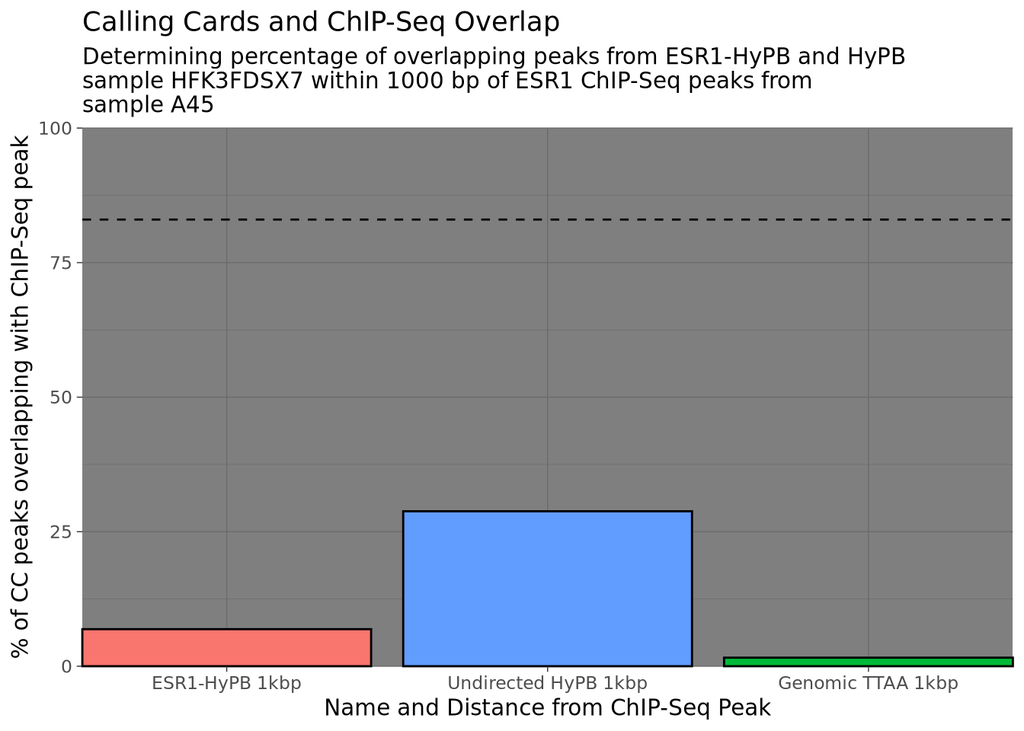

### Figure 2

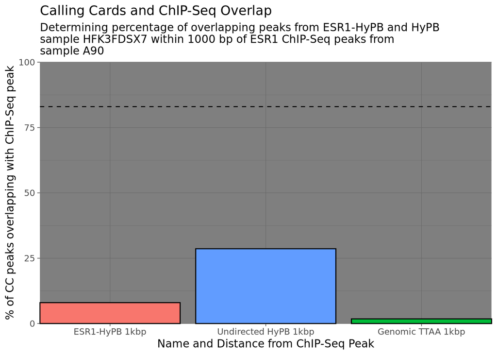

As you can see, there is both very little difference in the number of overlapping reads and very little difference between the overlap in A45 and A90. This was confirmed in the other replicates and as such the 45 minute samples will not be discussed further.

I found it surprising that so few HyPB-ER peaks overlapped with ChIP-Seq peaks and that the undirected calling cards had more overlap than ER directed, so I plotted the results from the remaining ChIP-Seq samples to see how they look.

## Calling cards with 1000 bp overlap window with one ChIP-Seq replicate - B90, C90, D90

### Figure 3

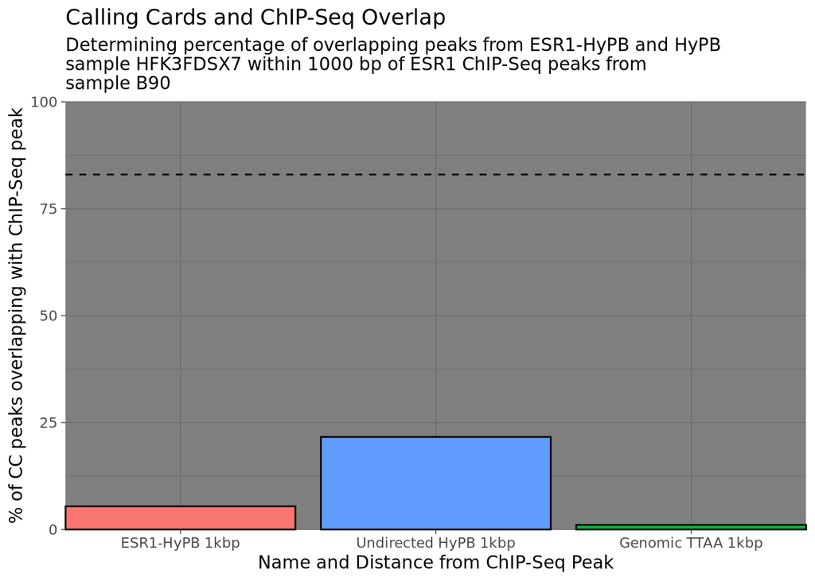

### Figure 4

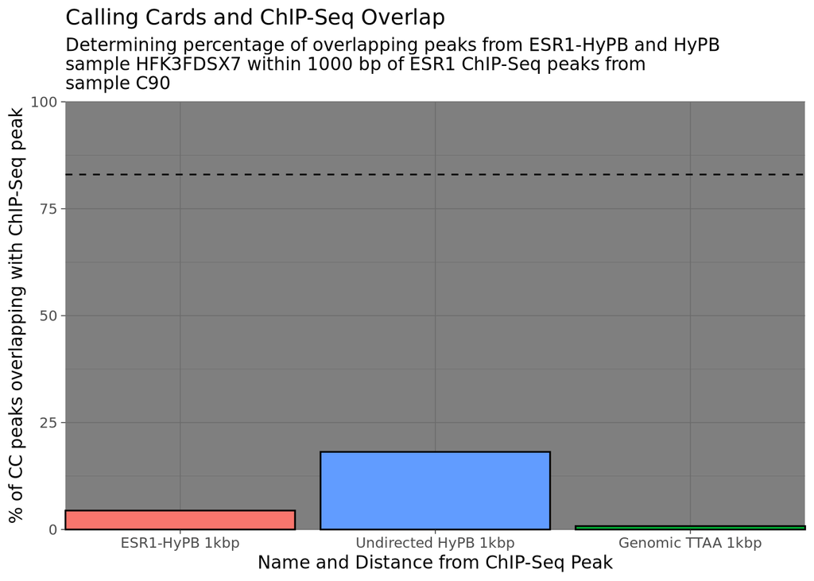

### Figure 5

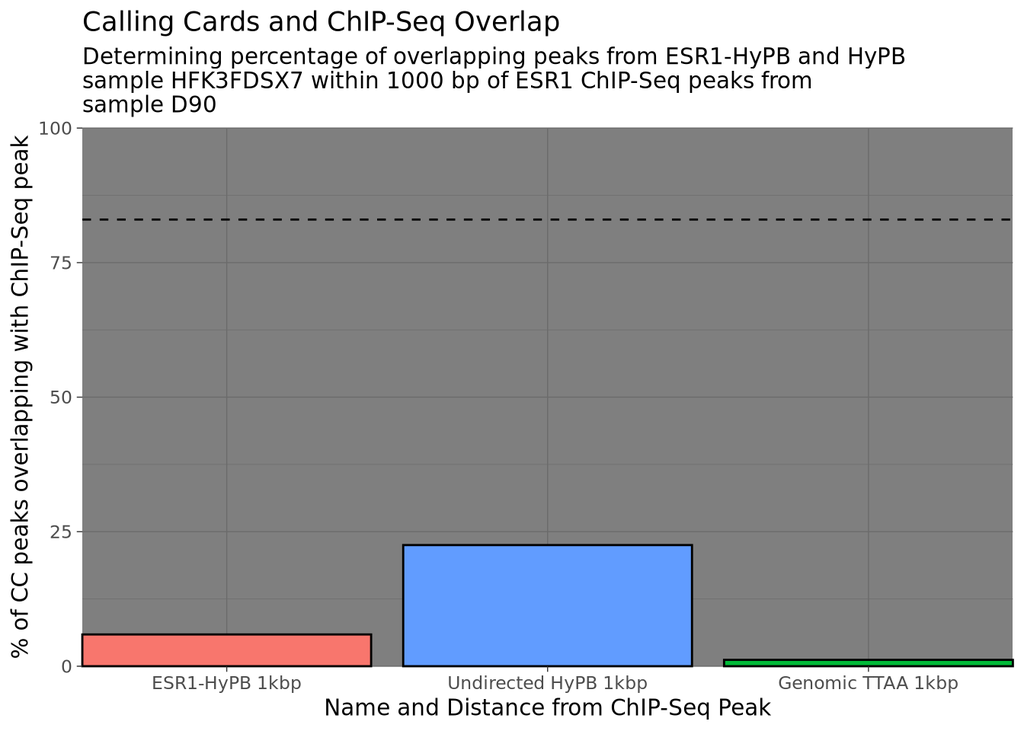

Unfortunately, it appears that all CC overlap with these ChIP-Seq peaks is also very low and undirected peaks are overlapping much more than directed. This was the same when using the peak files provided in the Moudgil et al., 2020.

## Increasing Calling Cards window up to 100,000 bp to assess overlap with ChIP-Seq peaks - A90 and C90

To see if eventually overlap would be saturated if the window size increases, I wrote a script to increase the window size up to 100,000 bp. In theory, as the window gets larger and larger, eventually all of the reads should overlap with a ChIP-Seq peak.

ChIP-Seq samples A90 and C90 were used as they represent the samples with the most and least overlap with CC peaks respectively.

### Figure 6

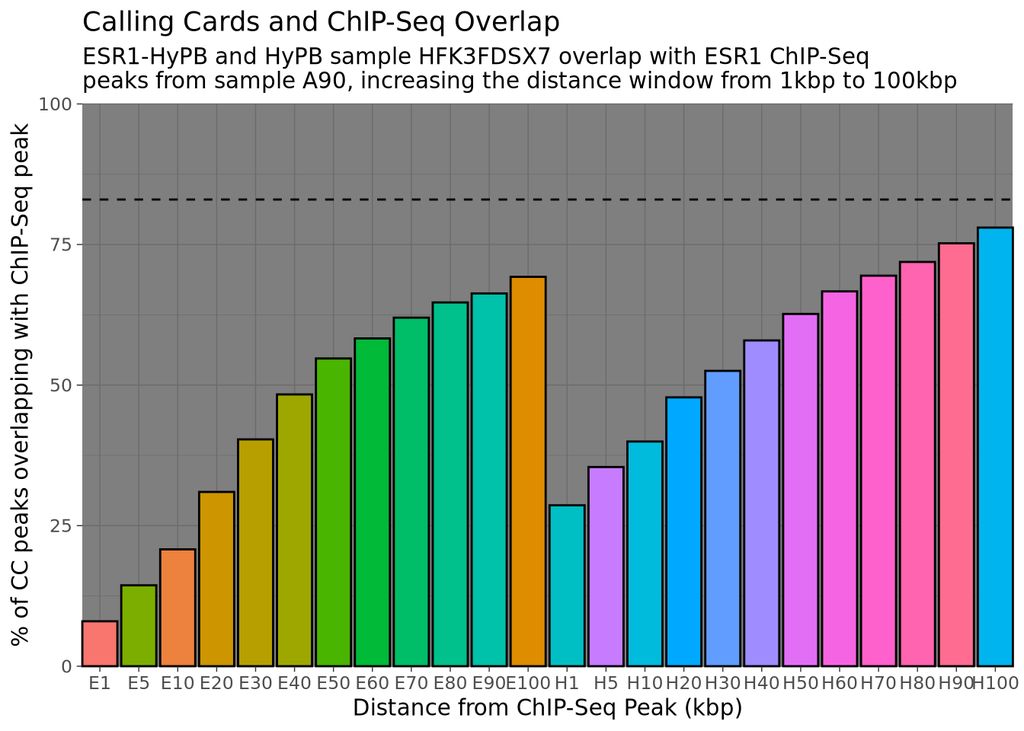

### Figure 7

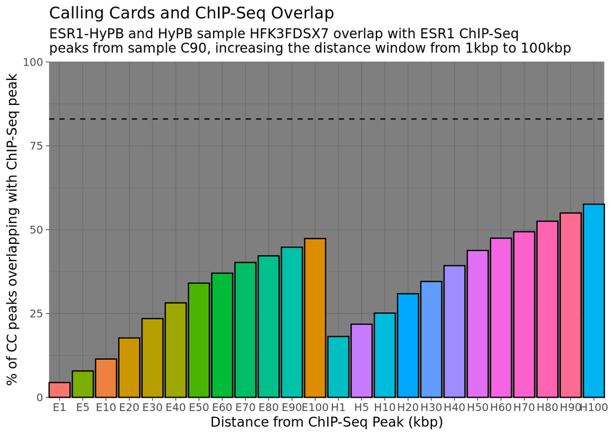

Although these plots show a trend up to saturation, neither of them make it to 83% - the percentage found in Wang et al., 2012. This is concerning and I’m not sure what is causing both the lack over ESR1 directed CC overlap with ChIP-Seq and why the undirected calling cards are overlapping more than the directed.

# Discussion

I have a hypothesis that this apparent lack of overlap is actually being caused by the Bayesian block method of analysis. The undirected HyPB has an affinity for BRD4, shown by their co-immunoprecipitation, which means that it will be inserting SRTs into enhancer and super enhancer sites. ESR1 is thought to act as a mediator of enchancer and promoter interaction, meaning that both ESR1 and BRD4 could be co-occupying the same sites. This could be having an effect where the undirected insertions are clustered in very similar places to directed insertions, so that when the Baysean block are made, the peak calling program might not be able to correctly identify the difference between background and genuine signal - effectively masking or diminishing the signal.

I believe this is supported by the fact that gene ontology shows that alot of the most represented genes in ER directed and undirected calling cards are the same.

# Future directions

I will re-analyse this data, ensuring no mistakes have been made in the processing. I will also combine the two ER flow cell files as well as the ChIP-Seq replicates for increased statistical power.

Another suggestion made by Andy was to subtract a BRD4 ChIP-Seq bed file from my ER ChIP-Seq. This should, in theory, remove all of the enhancer sites that would be bound in these cells and if used to run the bedtools window analysis, it could be used to give an indication whether my hypothesis is correct. It could then be tested by trying to find alternative analysis methods.